# STA 483 Project Part 1

# 4

### Monthly mean CO levels by station table

```r
co = madrid[!is.na(madrid$CO),] # remove all rows with CO = NA
co = co %>%
  select(date, CO, station) # remove all unnecessary columns

# use POSIXlt to extract month
dates.co = as.POSIXlt(co$date, format = "%Y-%m-%d%H:%M")
co.mon = data.frame("CO" = co$CO, "station" = co$station)
co.mon$month = dates.co$mon + 1

# grouped by station then month
means.co = co.mon %>%
  group_by(station, month) %>%
  summarise(mean = mean(CO))
head(means.co)
```

```
## # A tibble: 6 x 3
## # Groups:   station [1]
##    station month  mean
##      <int> <dbl> <dbl>
## 1 28079004     1 0.513
## 2 28079004     2 0.391
## 3 28079004     3 0.361
## 4 28079004     4 0.421
## 5 28079004     5 0.379
## 6 28079004     6 0.351
```

### Which site appears to have the largest levels of carbon monoxide?

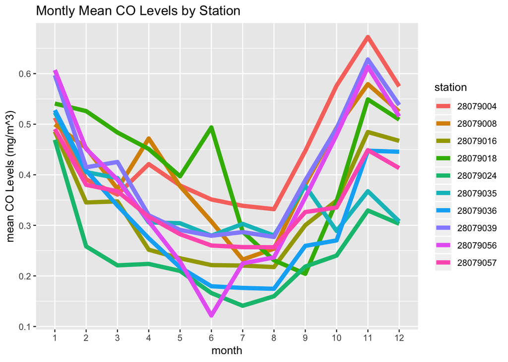

```r
means.co$station = as.factor(means.co$station) # convert station to factor for plotting
means.co$month = as.factor(means.co$month) # convert month to factor for plotting

ggplot(means.co, aes(month, mean)) +
  labs(y="mean CO Levels (mg/m^3)") +
  geom_line(aes(group = station, color = station), size = 2) +
  ggtitle("Montly Mean CO Levels by Station")
```

It appears that for the first half of the year the station with the highest monthly mean CO levels is Farolillo (28079018) and for the second half of the year it’s Pza. de Espana (28079004).

### Which month appears to have the largest levels of carbon monoxide?

```r
# grouped by month only
means.co.mon = co.mon %>%
  group_by(month) %>%
  summarise(mean = mean(CO))

# month with the highest average CO levels
means.co.mon[which.max(means.co.mon$mean),]
```

```
## # A tibble: 1 x 2
##   month  mean
##   <dbl> <dbl>
## 1     1 0.526
```

The month with the largest levels of carbon monoxide levels is January.

# 5

### monthly CO standard deviations by station table

```r
# grouped by station then month
sd.co = co.mon %>%
  group_by(station, month) %>%
  summarise(sd = sd(CO))
head(sd.co)
```

```
## # A tibble: 6 x 3
## # Groups:   station [1]
##    station month    sd
##      <int> <dbl> <dbl>
## 1 28079004     1 0.288
## 2 28079004     2 0.257
## 3 28079004     3 0.241
## 4 28079004     4 0.166
## 5 28079004     5 0.137
## 6 28079004     6 0.151
```

### Which site appears to be most variable in terms of carbon monoxide?

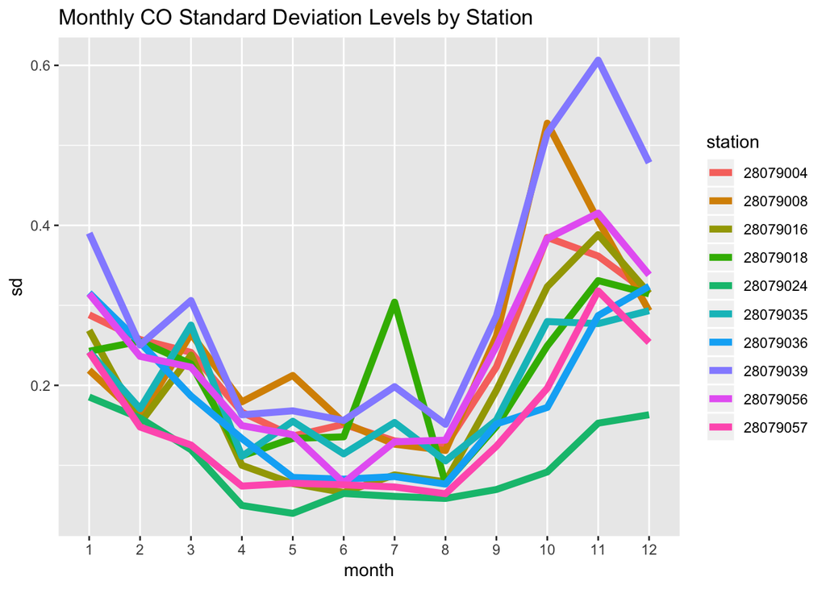

```r
sd.co$station = as.factor(sd.co$station) # convert station to factor for plotting
sd.co$month = as.factor(sd.co$month) # convert month to factor for plotting

ggplot(sd.co, aes(month, sd)) +
  geom_line(aes(group = station, color = station), size = 2) +
  ggtitle("Monthly CO Standard Deviation Levels by Station")
```

The most variable station in terms of CO is Barrio del Pilar (28079039), while the least variable station in terms of CO is Casa de Campo (28079024).

# 6

### Hourly mean NO2 levels by station table (only top 5 yearly stations)

```r
no2 = madrid[!is.na(madrid$NO_2),] # remove all rows with CO = NA
no2 = no2 %>%
  select(date, NO_2, station) # remove all unnecessary columns

# use POSIXlt to extract month
dates.no2 = as.POSIXlt(no2$date, format = "%Y-%m-%d%H:%M")
no2.hour = data.frame("NO_2" = no2$NO_2, "station" = no2$station)
no2.hour$hour = dates.no2$hour
no2.hour$year = dates.no2$year + 1900

# grouped by station then year
means.no2.year = no2.hour %>%
  group_by(station, year) %>%
  summarise(mean = mean(NO_2)) %>%
  arrange(desc(mean))
head(means.no2.year, n=5) # top 5 stations to display in hourly table
```

```
## # A tibble: 5 x 3
## # Groups:   station [5]
##    station  year  mean
##      <int> <dbl> <dbl>
## 1 28079008  2017  61.9
## 2 28079056  2017  59.2
## 3 28079004  2017  49.4
## 4 28079035  2017  49.1
## 5 28079017  2017  48.6
```

```r
# grouped by station then hour
means.no2 = no2.hour %>%
  group_by(station, hour) %>%
  summarise(mean = mean(NO_2)) %>%
  filter(station %in% c(28079008, 28079056, 28079004, 28079035, 28079017))
head(means.no2)
```

```
## # A tibble: 6 x 3
## # Groups:   station [1]
##    station  hour  mean
##      <int> <int> <dbl>
## 1 28079004     0  63.3
## 2 28079004     1  53.9
## 3 28079004     2  46.1
## 4 28079004     3  38.7
## 5 28079004     4  33.5
## 6 28079004     5  29.0
```

The above table appears to be broken into two groups: the first are the stations with the 2 highest mean NO2 levels, each within the (59-62) range, and the next are the next three highest, each falling into a (48.6 - 49.4) range. There is a clear distinction between the top two stations mean NO2 levels and that of the rest, so we can likely find some factor shared between those 2 stations that causes them to have such significantly higher mean levels than the other 3. The elevation is fairly different between these two top sites so we can probably rule that out as a significant predictive factor of NO2 level.

# 7

### Time Series plot of the mean NO2 levels for all of madrid

```r
no2.hour$month = dates.no2$mon + 1
no2.hour$day = dates.no2$wday
head(no2.hour)
```

```
##   NO_2  station hour year month day
## 1   38 28079004    1 2017     6   4
## 2   39 28079008    1 2017     6   4
## 3   14 28079011    1 2017     6   4
## 4    9 28079016    1 2017     6   4
## 5   19 28079017    1 2017     6   4
## 6   26 28079018    1 2017     6   4
```

```r
means.no2.all = no2.hour %>%
  group_by(year, month, day, hour) %>%
  summarise(mean = mean(NO_2))
head(means.no2.all)
```

```
## # A tibble: 6 x 5
## # Groups:   year, month, day [1]
##    year month   day  hour  mean
##   <dbl> <dbl> <int> <int> <dbl>
## 1  2017     1     0     0  73.6
## 2  2017     1     0     1  63.2
## 3  2017     1     0     2  60.6
## 4  2017     1     0     3  53.6
## 5  2017     1     0     4  49.2
## 6  2017     1     0     5  44.7
```

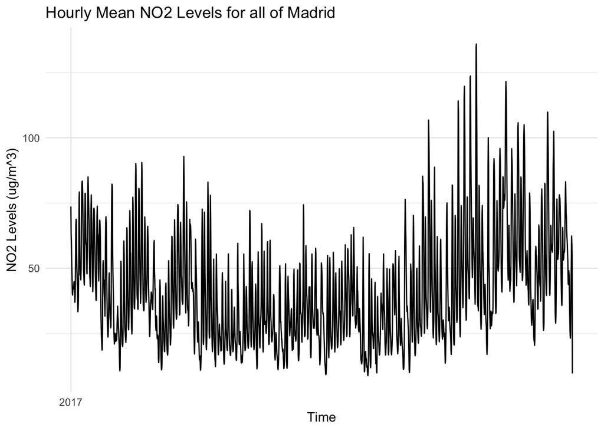

```r
no2.all.ts = ts(means.no2.all$mean, start=c(2017,1,0,0), frequency = 8760)
autoplot(no2.all.ts, bands = T) +
  labs(x="Time", y="NO2 Levels (ug/m^3)") +
  ggtitle("Hourly Mean NO2 Levels for all of Madrid") +
  theme_minimal()
```

# 8

### Map of Mean NO2 Levels at Each Station

[figure not shown]

```r
means.no2.map = no2.hour %>%
  group_by(station) %>%
  summarise(mean = mean(NO_2))
colnames(means.no2.map)[1] = "id" # change variable name to match "stations" data so we can join

means.no2.map = means.no2.map %>%
  left_join(stations, by = "id")

##########
# retrieved from stackoverflow. I set up a Google Static Maps API and created a key but it would throw an error when retrieving.
# The comment on the post said there's a issue with the currently published version and provided the following lines to fix ..
if(!requireNamespace("devtools")) install.packages("devtools")
devtools::install_github("dkahle/ggmap", ref = "tidyup")
library(ggmap)
register_google(key = "AIzaSyB5C3GHAmzoiwLbt8tSEyxmrx7OEnw0zwY")
# citation:
# D. Kahle and H. Wickham. ggmap: Spatial Visualization with ggplot2. The R Journal, 5(1), 144-161. URL
#  http://journal.r-project.org/archive/2013-1/kahle-wickham.pdf
##########

spain<- get_googlemap(center = c(lon = -3.700279, lat = 40.396375), zoom=11,maptype = "roadmap", color = "bw")
# used google maps to find general latitude and longitude of Madrid

ggmap(spain) +
  ggtitle("Mean NO2 Levels by Station in Madrid") +
  geom_point(data=means.no2.map,
             aes(x=lon, y=lat, size=2, colour = mean), alpha=I(0.7)) +
  scale_colour_gradient(low = "red", high = "green")
```